# Tipologia i cicle de vida de les dades: Pràctica 2

Autors: Alexandre Casanovas / Antonio Nogueras

Juny 2021

*Càrrega del fitxer*

```r
Titanic <- read.csv("all_Titanic.csv",stringsAsFactors = FALSE, sep=';',fileEncoding = "WINDOWS-1252")
head(Titanic)
```

```
##                               Name Age Boarded  Position Lifeboat  Body Sex
## 1             Mr. George Swane[63]  19       S chauffeur          294MB   m
## 2 Miss Amelia Mary "Mildred" Brown  18       S      cook       11         f
## 3               Miss Sarah Daniels  33       S      maid        8         f
## 4     Miss Alice Catherine Cleaver  22       S     nurse       11         f
## 5              Miss Rosalie Bidois  46       C      maid        4         f
## 6      Miss Caroline Louise Endres  39       C     nurse        4         f
##   Class      Group
## 1     2 1classServ
## 2     2 1classServ
## 3     1 1classServ
## 4     1 1classServ
## 5     1 1classServ
## 6     1 1classServ
```

*Neteja de les dades*

*Duplicats*

```r
anyDuplicated(Titanic$Name)
```

```
## [1] 927
```

```r
anyDuplicated(Titanic)
```

```
## [1] 0
```

```r
duplicated_name <- data.frame(table(Titanic$Name))
duplicated_name[duplicated_name$Freq > 1,]
```

```
##                               Var1 Freq
## 145          Barnes, Mr. Frederick    2
## 216              Blake, Mr. Seaton    2
## 417              Coleman, Mr. John    2
## 459      Coutin, Mr. Auguste Louis    2
## 548  Desvernine, Mr. Louis Gabriel    2
## 690              Fraser, Mr. James    2
## 827             Harris, Mr. Edward    2
## 1053              Kelly, Mr. James    3
## 1688       Rice, Mr. John Reginald    2
## 1793              Saunders, Mr. W.    2
```

```r
#Creem columna ID per tenir una columna unique ja que la columna Name no ho és
Titanic$ID <- seq.int(nrow(Titanic))
Titanic <- Titanic[,c("ID","Name","Age","Boarded","Position","Lifeboat","Body","Sex","Class","Group")]
head(Titanic)
```

```
##   ID                             Name Age Boarded  Position Lifeboat  Body Sex
## 1  1             Mr. George Swane[63]  19       S chauffeur          294MB   m
## 2  2 Miss Amelia Mary "Mildred" Brown  18       S      cook       11         f
## 3  3               Miss Sarah Daniels  33       S      maid        8         f
## 4  4     Miss Alice Catherine Cleaver  22       S     nurse       11         f
## 5  5              Miss Rosalie Bidois  46       C      maid        4         f
## 6  6      Miss Caroline Louise Endres  39       C     nurse        4         f
##   Class      Group
## 1     2 1classServ
## 2     2 1classServ
## 3     1 1classServ
## 4     1 1classServ
## 5     1 1classServ
## 6     1 1classServ
```

```r
summary(Titanic$Age)
```

```
##    Length     Class      Mode
##      2177 character character
```

*Correcció de caràcters extranys a Name*

```r
#Eliminem el que hi ha entre [] a Name
I <- grep("\\[*]",Titanic$Name)
Titanic$Name[I] <- gsub("\\[\\d{2}\\]","",Titanic$Name[I])
head(Titanic)
```

```
##   ID                             Name Age Boarded  Position Lifeboat  Body Sex
## 1  1                 Mr. George Swane  19       S chauffeur          294MB   m
## 2  2 Miss Amelia Mary "Mildred" Brown  18       S      cook       11         f
## 3  3               Miss Sarah Daniels  33       S      maid        8         f
## 4  4     Miss Alice Catherine Cleaver  22       S     nurse       11         f
## 5  5              Miss Rosalie Bidois  46       C      maid        4         f
## 6  6      Miss Caroline Louise Endres  39       C     nurse        4         f
##   Class      Group
## 1     2 1classServ
## 2     2 1classServ
## 3     1 1classServ
## 4     1 1classServ
## 5     1 1classServ
## 6     1 1classServ
```

*Valors nulls i valors incorrectes*

```r
nrow(Titanic)
```

```
## [1] 2177
```

```r
length(Titanic$Name[Titanic$Name == ""])
```

```
## [1] 0
```

```r
sum(is.na(Titanic$Name))
```

```
## [1] 0
```

```r
length(Titanic$Age[Titanic$Age == ""])
```

```
## [1] 1
```

```r
sum(is.na(Titanic$Age))
```

```
## [1] 0
```

```r
table(Titanic$Age)
```

```
##
##       0,166  0,25  0,42  0,58  0,75 0,833 0,916     1    10    11    12    13
##     1     1     1     1     1     2     3     1    11     6     4     5     6
##    14    15    16    17    18    19     2    20    21    22    23    24    25
##     9    11    27    38    58    62    13    80    82    97    67    88    88
##    26    27    28    29     3    30    31    32    33    34    35    36    37
##    73    77    90    77     7    97    75    91    51    54    59    70    42
##    38    39     4    40    41    42    43    44    45    46    47    48    49
##    44    54    15    43    30    39    25    26    32    17    19    23    13
##     5    50    51    52    53    54    55    56    57    58    59     6    60
##     5    16    10    12     3    10     9     5     7     7     9     5     8
##    61    62    63    64    65    66    67    69     7    70    71    74     8
##     7     8     7     5     1     3     1     1     9     1     3     1     9
##     9
##     9
```

```r
length(Titanic$Boarded[Titanic$Boarded == ""])
```

```
## [1] 62
```

```r
sum(is.na(Titanic$Boarded))
```

```
## [1] 0
```

```r
table(Titanic$Boarded)
```

```
##
##         B    C    Q    S
##   62  173  258  120 1564
```

```r
length(Titanic$Position[Titanic$Position == ""])
```

```
## [1] 0
```

```r
sum(is.na(Titanic$Position))
```

```
## [1] 0
```

```r
table(Titanic$Position)
```

```
##
##                            1classPass                            2classPass
##                                   284                                   278
##                            3classPass                           Able Seaman
##                                   708                                    32
##                       Assistant Baker               Assistant Boots Steward
##                                     2                                     1
##                     Assistant Butcher                        Assistant Chef
##                                     1                                     1
##               Assistant Deck Engineer                Assistant Deck Steward
##                                     1                                     1
##                 Assistant Electrician             Assistant Fourth Engineer
##                                     4                                     1
##              Assistant Lounge Steward                      Assistant Pantry
##                                     1                                     1
##              Assistant Pantry Steward                   Assistant Pantryman
##                                     2                                     1
##           Assistant Pantryman Steward                Assistant Passage Cook
##                                     5                                     1
##                 Assistant Pastry Cook             Assistant Printer Steward
##                                     1                                     1
##                      Assistant Purser                  Assistant Roast Cook
##                                     1                                     1
##              Assistant Saloon Steward Assistant Second Class Saloon Steward
##                                     9                                     1
##             Assistant Second Engineer                 Assistant Ship's Cook
##                                     1                                     1
##          Assistant Smoke Room Steward                 Assistant Storekeeper
##                                     1                                     2
##                     Assistant Surgeon                Assistant Telegraphist
##                                     1                                     1
##              Assistant Vegetable Cook                           Asst. Baker
##                                     4                                     1
##                         Asst. Butcher                      Asst. Controller
##                                     1                                     1
##                            Asst. Cook                       Asst. Fish Cook
##                                     1                                     1
##                       Asst. Glass Man                     Asst. Larder Cook
##                                     2                                     1
##                  Asst. Pantry Steward                       Asst. Pantryman
```

[output cut: 160 more lines]

```
##                                     9                                     1
##                  Third Saloon Steward                               Trimmer
##                                     1                                    74
##                Turkish Bath Attendant               Turkish Bath Stewardess
##                                     2                                     2
##                                 valet                        Vegetable Cook
##                                     7                                     1
##                      Verandah Steward                          Vienna Baker
##                                     1                                     1
##                             Violinist                                Waiter
##                                     2                                    15
##                        Window Cleaner                           Wine Butler
##                                     2                                     1
##               Writer/Engineer's Clerk
##                                     1
```

```r
length(Titanic$Lifeboat[Titanic$Lifeboat == ""])
```

```
## [1] 1489
```

```r
sum(is.na(Titanic$Lifeboat))
```

```
## [1] 0
```

```r
table(Titanic$Lifeboat)
```

```
##
##           ?     1    10    11    12    13    14    15    16     2     3  322M
##  1489    12    12    31    46    20    65    43    59    35    15    39     1
##     4     5     6     7     8     9     A A[68]  A/14     B     C     D
##    41    35    25    23    28    41    17     1     1    31    45    22
```

```r
length(Titanic$Body[Titanic$Body == ""])
```

```
## [1] 1921
```

```r
sum(is.na(Titanic$Body))
```

```
## [1] 0
```

```r
length(Titanic$Sex[Titanic$Sex == ""])
```

```
## [1] 0
```

```r
sum(is.na(Titanic$Sex))
```

```
## [1] 0
```

```r
table(Titanic$Sex)
```

```
##
##    f    m
##  469 1708
```

```r
length(Titanic$Class[Titanic$Class == ""])
```

```
## [1] 3
```

```r
sum(is.na(Titanic$Class))
```

```
## [1] 3
```

```r
table(Titanic$Class)
```

```
##
##   0   1   2   3
## 849 324 293 708
```

```r
length(Titanic$Group[Titanic$Group == ""])
```

```
## [1] 0
```

```r
sum(is.na(Titanic$Group))
```

```
## [1] 0
```

```r
table(Titanic$Group)
```

```
##
##      1c0ser     1c1serv     1c2serv  1classServ      2class      3class
##         250          28           6          41         278         708
##        Deck Engineering    garantee     officer   Orchestra     Postman
##          59         319           9           8           8           5
##  restaurant Victualling
##          69         389
```

```r
#Name no te nulls
#Age te nulls, eliminem els registres, i valors amb decimals, que també els eliminem
nrow(Titanic)
```

```
## [1] 2177
```

```r
Titanic <- Titanic[Titanic$Age != "",]
nrow(Titanic)
```

```
## [1] 2176
```

```r
Titanic$Age <- as.integer(Titanic$Age)
#Tots els valors no integer són NA, els eliminem
sum(is.na(Titanic$Age))
```

```
## [1] 10
```

```r
Titanic <- Titanic[!is.na(Titanic$Age),]
nrow(Titanic)
```

```
## [1] 2166
```

```r
#Eliminem els valors vuits de Boarded
Titanic <- Titanic[Titanic$Boarded != "",]
nrow(Titanic)
```

```
## [1] 2104
```

```r
#Position no te nulls
#Lifeboat ens indica la barca de salvament a la que pujem els supervivents, per tant els camps nulls ens indiquen que no van sobreviure mentre que els que pujen a una barca si, anem a crear una nova variable SURVIVED, 0 si no sobreviuen 1 si sobreviuen.
Titanic$Survived[Titanic$Lifeboat != ""] <- 1
Titanic$Survived[Titanic$Lifeboat == ""] <- 0
table(Titanic$Survived)
```

```
##
##    0    1
## 1432  672
```

```r
#Fem el mateix amb Body, en quest cas sobre la mateixa variable.
Titanic$Body[Titanic$Body != ""] <- 1
Titanic$Body[Titanic$Body == ""] <- 0
table(Titanic$Body)
```

```
##
##    0    1
## 1854  250
```

```r
#Sex no te nulls
#Eliminem nulls a Class
Titanic <- Titanic[Titanic$Class != "",]
Titanic <- Titanic[!is.na(Titanic$Class),]
nrow(Titanic)
```

```
## [1] 2101
```

```r
str(Titanic)
```

```
## 'data.frame':    2101 obs. of  11 variables:
##  $ ID      : int  1 2 3 4 5 6 7 8 9 10 ...
##  $ Name    : chr  "Mr. George Swane" "Miss Amelia Mary \"Mildred\" Brown" "Miss Sarah Daniels" "Miss Alice Catherine Cleaver" ...
##  $ Age     : int  19 18 33 22 46 39 25 36 38 35 ...
##  $ Boarded : chr  "S" "S" "S" "S" ...
##  $ Position: chr  "chauffeur" "cook" "maid" "nurse" ...
##  $ Lifeboat: chr  "" "11" "8" "11" ...
##  $ Body    : chr  "1" "0" "0" "0" ...
##  $ Sex     : chr  "m" "f" "f" "f" ...
##  $ Class   : int  2 2 1 1 1 1 1 1 1 1 ...
##  $ Group   : chr  "1classServ" "1classServ" "1classServ" "1classServ" ...
##  $ Survived: num  0 1 1 1 1 1 1 1 1 1 ...
```

```r
summary(Titanic)
```

```
##        ID           Name                Age          Boarded
##  Min.   :   1   Length:2101        Min.   : 1.00   Length:2101
##  1st Qu.: 528   Class :character   1st Qu.:22.00   Class :character
##  Median :1059   Mode  :character   Median :29.00   Mode  :character
##  Mean   :1076                      Mean   :30.09
##  3rd Qu.:1649                      3rd Qu.:37.00
##  Max.   :2177                      Max.   :74.00
##    Position           Lifeboat             Body               Sex
##  Length:2101        Length:2101        Length:2101        Length:2101
##  Class :character   Class :character   Class :character   Class :character
##  Mode  :character   Mode  :character   Mode  :character   Mode  :character
##
##
##
##      Class          Group              Survived
##  Min.   :0.000   Length:2101        Min.   :0.0000
##  1st Qu.:0.000   Class :character   1st Qu.:0.0000
##  Median :1.000   Mode  :character   Median :0.0000
##  Mean   :1.432                      Mean   :0.3198
##  3rd Qu.:3.000                      3rd Qu.:1.0000
##  Max.   :3.000                      Max.   :1.0000
```

*Busquem outliers sobre Age*

```r
summary(Titanic$Age)
```

```
##    Min. 1st Qu.  Median    Mean 3rd Qu.    Max.
##    1.00   22.00   29.00   30.09   37.00   74.00
```

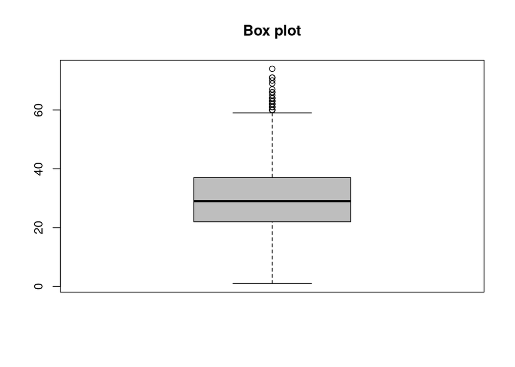

```r
boxplot(Titanic$Age,main="Box plot", col="gray")
```

La mitjana d’edat està a 30.09 i el mínim en 1 i el màxim en 74. El rang interquartil està entre 22 i 37 anys, amb el que el gràfic deixa com a outliers totes les edats per sonre de 60 anys. A la realitat savem que aixó no és cert, no són edats fora de el normal, simplement que la mitjana d’edat és baixa, el normal en un viatge amb baixell tan llarg pels principis de segle XX.

*Categoritzem la variable Age*

Anem a categoritzar la variable Age, entre Adults i Menors, considerant els segons com els menors de 15 anys

```r
ma = max(Titanic$Age)
mi = min(Titanic$Age)
Titanic$Adult <-cut(Titanic$Age, breaks = c(mi,14,ma),include.lowest = TRUE,labels = c(0,1))
summary(Titanic$Adult)
```

```
##    0    1
##  113 1988
```

*Per últim anem a crear variables acumulatives*

```r
Titanic$cClass0[Titanic$Class == 0] <- 1
Titanic$cClass0[Titanic$Class == 1] <- 0
Titanic$cClass0[Titanic$Class == 2] <- 0
Titanic$cClass0[Titanic$Class == 3] <- 0
Titanic$cClass1[Titanic$Class == 0] <- 0
Titanic$cClass1[Titanic$Class == 1] <- 1
Titanic$cClass1[Titanic$Class == 2] <- 0
Titanic$cClass1[Titanic$Class == 3] <- 0
Titanic$cClass2[Titanic$Class == 0] <- 0
Titanic$cClass2[Titanic$Class == 1] <- 0
Titanic$cClass2[Titanic$Class == 2] <- 1
Titanic$cClass2[Titanic$Class == 3] <- 0
Titanic$cClass3[Titanic$Class == 0] <- 0
Titanic$cClass3[Titanic$Class == 1] <- 0
Titanic$cClass3[Titanic$Class == 2] <- 0
Titanic$cClass3[Titanic$Class == 3] <- 1
Titanic$cSex[Titanic$Sex == "f"] <- 1
Titanic$cSex[Titanic$Sex == "m"] <- 0
Titanic$cSex <- cumsum(Titanic$cSex)
Titanic$cSurvived <- cumsum(Titanic$Survived)
Titanic$cAdult <- cumsum(as.numeric(Titanic$Adult))
Titanic$cClass0 <- cumsum(Titanic$cClass0)
Titanic$cClass1 <- cumsum(Titanic$cClass1)
Titanic$cClass2 <- cumsum(Titanic$cClass2)
Titanic$cClass3 <- cumsum(Titanic$cClass3)
```

*Guardem el nou dataframe*

```r
write.csv(Titanic,"~/Desktop/data_science/dades/neteja/Titanic.csv")
```

*Agafem les variables amb les que farem l’estudi*

```r
estudi <- c("Adult", "Class", "Sex", "Survived")
Titanic_S <- Titanic[estudi]
#Convertim les variables en categóriques
Titanic_S$Survived <- as.factor(Titanic_S$Survived)
Titanic_S$Adult <- as.factor(Titanic_S$Adult)
Titanic_S$Class <- as.factor(Titanic_S$Class)
Titanic_S$Sex <- as.factor(Titanic_S$Sex)
summary(Titanic_S)
```

```
##  Adult    Class   Sex      Survived
##  0: 113   0:786   f: 466   0:1429
##  1:1988   1:323   m:1635   1: 672
##           2:290
##           3:702
```

*Estudi de correlació*

```r
#Convertim la variable Sex a numeric
Titanic[estudi]$Sex[Titanic$Sex == "f"] <- 1
Titanic[estudi]$Sex[Titanic$Sex == "m"] <- 0
Titanic[estudi]$Sex <- as.numeric(Titanic[estudi]$Sex)
Titanic[estudi]$Adult <- as.numeric(Titanic[estudi]$Adult)
cor(Titanic[estudi])
```

```
##                Adult       Class        Sex    Survived
## Adult     1.00000000 -0.23103560 -0.1520305 -0.07173064
## Class    -0.23103560  1.00000000  0.2511492 -0.01458246
## Sex      -0.15203049  0.25114922  1.0000000  0.45674303
## Survived -0.07173064 -0.01458246  0.4567430  1.00000000
```

La primer intenció era fer un estudi de regressió logística sobre la variable Survived, peró degut a la poca correlació entre les variables, només Sex te certa correlació amb Survived, optem per un altre enfocament.

Utilitzarem les variables acumulatives creades anteriorment i farem un estudi de regressió lineal.

```r
cor(Titanic[c("cSurvived", "cSex", "cAdult", "cClass0", "cClass1", "cClass2", "cClass3")])
```

```
##           cSurvived      cSex    cAdult   cClass0   cClass1   cClass2   cClass3
## cSurvived 1.0000000 0.9805499 0.9815914 0.7242037 0.6916556 0.8527876 0.9217838
## cSex      0.9805499 1.0000000 0.9427709 0.5906714 0.6966437 0.8878291 0.9403003
## cAdult    0.9815914 0.9427709 1.0000000 0.8236857 0.5636606 0.7619894 0.9389442
## cClass0   0.7242037 0.5906714 0.8236857 1.0000000 0.2328246 0.3675143 0.6535809
## cClass1   0.6916556 0.6966437 0.5636606 0.2328246 1.0000000 0.7304298 0.4534333
## cClass2   0.8527876 0.8878291 0.7619894 0.3675143 0.7304298 1.0000000 0.7119293
## cClass3   0.9217838 0.9403003 0.9389442 0.6535809 0.4534333 0.7119293 1.0000000
```

En aquest cas si que veiem correlació entre aquestes variables i seran les que utilitzarem per fer un estudi de regressió lineal.

*Comprovació de la normalitat i homogeneïtat de la variància*

*Homogeneitat de la variància*

```r
var.test(as.numeric(Titanic_S$Survived), as.numeric(Titanic_S$Adult))
```

```
##
##  F test to compare two variances
##
## data:  as.numeric(Titanic_S$Survived) and as.numeric(Titanic_S$Adult)
## F = 4.2747, num df = 2100, denom df = 2100, p-value < 2.2e-16
## alternative hypothesis: true ratio of variances is not equal to 1
## 95 percent confidence interval:
##  3.924164 4.656571
## sample estimates:
## ratio of variances
##            4.27471
```

```r
var.test(as.numeric(Titanic_S$Survived), as.numeric(Titanic_S$Class))
```

```
##
##  F test to compare two variances
##
## data:  as.numeric(Titanic_S$Survived) and as.numeric(Titanic_S$Class)
## F = 0.1309, num df = 2100, denom df = 2100, p-value < 2.2e-16
## alternative hypothesis: true ratio of variances is not equal to 1
## 95 percent confidence interval:
##  0.1201692 0.1425977
## sample estimates:
## ratio of variances
##           0.130904
```

```r
var.test(as.numeric(Titanic_S$Survived), as.numeric(Titanic_S$Sex))
```

```
##
##  F test to compare two variances
##
## data:  as.numeric(Titanic_S$Survived) and as.numeric(Titanic_S$Sex)
## F = 1.2604, num df = 2100, denom df = 2100, p-value = 1.186e-07
## alternative hypothesis: true ratio of variances is not equal to 1
## 95 percent confidence interval:
##  1.157013 1.372958
## sample estimates:
## ratio of variances
##           1.260369
```

```r
var.test(as.numeric(Titanic$cSurvived), as.numeric(Titanic$cAdult))
```

```
##
##  F test to compare two variances
##
## data:  as.numeric(Titanic$cSurvived) and as.numeric(Titanic$cAdult)
## F = 0.02204, num df = 2100, denom df = 2100, p-value < 2.2e-16
## alternative hypothesis: true ratio of variances is not equal to 1
## 95 percent confidence interval:
##  0.02023281 0.02400907
## sample estimates:
## ratio of variances
##         0.02204022
```

```r
var.test(as.numeric(Titanic$cSurvived), as.numeric(Titanic$cClass0))
```

```
##
##  F test to compare two variances
##
## data:  as.numeric(Titanic$cSurvived) and as.numeric(Titanic$cClass0)
## F = 0.52505, num df = 2100, denom df = 2100, p-value < 2.2e-16
## alternative hypothesis: true ratio of variances is not equal to 1
## 95 percent confidence interval:
##  0.4819964 0.5719564
## sample estimates:
## ratio of variances
##          0.5250533
```

```r
var.test(as.numeric(Titanic$cSurvived), as.numeric(Titanic$cClass1))
```

```
##
##  F test to compare two variances
##
## data:  as.numeric(Titanic$cSurvived) and as.numeric(Titanic$cClass1)
## F = 6.3637, num df = 2100, denom df = 2100, p-value < 2.2e-16
## alternative hypothesis: true ratio of variances is not equal to 1
## 95 percent confidence interval:
##  5.841805 6.932122
## sample estimates:
## ratio of variances
##           6.363655
```

```r
var.test(as.numeric(Titanic$cSurvived), as.numeric(Titanic$cClass2))
```

```
##
##  F test to compare two variances
##
## data:  as.numeric(Titanic$cSurvived) and as.numeric(Titanic$cClass2)
## F = 2.6606, num df = 2100, denom df = 2100, p-value < 2.2e-16
## alternative hypothesis: true ratio of variances is not equal to 1
## 95 percent confidence interval:
##  2.442418 2.898272
## sample estimates:
## ratio of variances
##             2.6606
```

```r
var.test(as.numeric(Titanic$cSurvived), as.numeric(Titanic$cClass3))
```

```
##
##  F test to compare two variances
##
## data:  as.numeric(Titanic$cSurvived) and as.numeric(Titanic$cClass3)
## F = 0.31936, num df = 2100, denom df = 2100, p-value < 2.2e-16
## alternative hypothesis: true ratio of variances is not equal to 1
## 95 percent confidence interval:
##  0.2931669 0.3478836
## sample estimates:
## ratio of variances
##          0.3193555
```

```r
var.test(as.numeric(Titanic$cSurvived), as.numeric(Titanic$cSex))
```

```
##
##  F test to compare two variances
##
## data:  as.numeric(Titanic$cSurvived) and as.numeric(Titanic$cSex)
## F = 1.518, num df = 2100, denom df = 2100, p-value < 2.2e-16
## alternative hypothesis: true ratio of variances is not equal to 1
## 95 percent confidence interval:
##  1.393482 1.653562
## sample estimates:
## ratio of variances
##           1.517962
```

Els p-values són tots molt propers a 0 i menors que 0.05, per tant podem rebutjar la hipòtesis nul-la, per tant podem dir que les variàncies no són iguals i asssumim heterocedasticitat.

```r
library(nortest)
ad.test(Titanic$cSurvived)
```

```
##
##  Anderson-Darling normality test
##
## data:  Titanic$cSurvived
## A = 29.745, p-value < 2.2e-16
```

```r
ad.test(Titanic$cAdult)
```

```
##
##  Anderson-Darling normality test
##
## data:  Titanic$cAdult
## A = 21.639, p-value < 2.2e-16
```

```r
ad.test(Titanic$cSex)
```

```
##
##  Anderson-Darling normality test
##
## data:  Titanic$cSex
## A = 118.97, p-value < 2.2e-16
```

```r
ad.test(Titanic$cClass0)
```

```
##
##  Anderson-Darling normality test
##
## data:  Titanic$cClass0
## A = 312.24, p-value < 2.2e-16
```

```r
ad.test(Titanic$cClass1)
```

```
##
##  Anderson-Darling normality test
##
## data:  Titanic$cClass1
## A = 574.64, p-value < 2.2e-16
```

```r
ad.test(Titanic$cClass2)
```

```
##
##  Anderson-Darling normality test
##
## data:  Titanic$cClass2
## A = 431.64, p-value < 2.2e-16
```

```r
ad.test(Titanic$cClass3)
```

```
##
##  Anderson-Darling normality test
##
## data:  Titanic$cClass3
## A = 195.41, p-value < 2.2e-16
```

Els p-values són tots molt propers a 0 i menors que 0.05, per tant podem rebutjar la hipòtesis nul-la, per tant podem dir que les distribucions no són normals.